# Introduction to NLP for Social Sciences

## Sustainable Development Summer School

## Columbia University

## Nicolas Longuet Marx

### June 7, 2022

### Notebook and slides available at: https://github.com/nicolaslonguetmarx/

Slides partially based on Elliott Ash's course materials

# Introduction

Why do we care about text?

- **Quantity:** Incredibly large quantity of text produced (500 million tweets per day, 6 billion emails per day, 2 million newspaper articles per day, etc.)
- **Availability:** Historical records as well as non official data
- **Type:** Contains more information than other sources (sentiments vs. votes $\rightarrow$ continuous vs. binary)

But:

- **High dimension**: set of tweets of size 30 words written using only the 1000 common words is of size 1000^30
- **Unstructured**: actual information is mixed with a lot of (economically) irrelevant data

## Today's session:

- How can we compare multiple texts with each other?
- Focus on Political texts: speeches in the U.S. Congress
- Data publicly available from Gentzkow, Shapiro, and Taddy (2019)

# Outline

1. Text Complexity
2. Count matrices and TF-IDF
3. Dictionary-based approaches
4. Topic Modeling: LDA
5. Word and Document Embedding

# 0. Load some libraries and import the data

U.S. Congress speches from [Gentzkow, Shapiro, and Taddy (2019).](https://data.stanford.edu/congress_text)

Today, we'll use only data from the 114th Congress (2015 - 2017)

```python
import pandas as pd
import numpy as np
import os
import re
import nltk
from nltk.corpus import stopwords
import textstat
import seaborn as sns
import matplotlib.pyplot as plt
import warnings
warnings.filterwarnings('ignore')
```

```python
# import the speaker map
speaker_map = pd.read_csv('114_SpeakerMap.txt',
                  encoding="ISO-8859-1",
                      sep="|")
```

```python
speaker_map.head()
```

|  | speakerid | speech_id | lastname | firstname | chamber | state | gender | party | district | nonvoting |
| --- | --- | --- | --- | --- | --- | --- | --- | --- | --- | --- |
| 0 | 114120480 | 1140000007 | MCMORRIS RODGERS | CATHY | H | WA | F | R | 5.0 | voting |
| 1 | 114118560 | 1140000009 | BECERRA | XAVIER | H | CA | M | D | 34.0 | voting |
| 2 | 114121890 | 1140000011 | MASSIE | THOMAS | H | KY | M | R | 4.0 | voting |
| 3 | 114122500 | 1140000013 | BRIDENSTINE | JIM | H | OK | M | R | 1.0 | voting |
| 4 | 114120780 | 1140000017 | PELOSI | NANCY | H | CA | F | D | 12.0 | voting |

```python
# import speeches

speeches = pd.read_csv('speeches_114.txt',
               encoding="ISO-8859-1",
               sep="|",
               on_bad_lines='skip',
               engine = 'python')
```

```python
speeches.head()
```

|  | speech_id | speech |
| --- | --- | --- |
| 0 | 1140000001 | The Representativeselect and their guests will... |
| 1 | 1140000002 | As directed by law. the Clerk of the House has... |
| 2 | 1140000003 | Four hundred and one Represent ativeselect hav... |
| 3 | 1140000004 | Credentials. regular in form. have been receiv... |
| 4 | 1140000005 | The Clerk is in receipt of a letter from the H... |

```python
# merge the map with the speeches
speaker_map_short = speaker_map[['speakerid', 'speech_id', 'party']]
speeches = speeches.merge(speaker_map_short, left_on='speech_id', right_on='speech_id')
```

```python
speeches.head()
```

|  | speech_id | speech | speakerid | party |
| --- | --- | --- | --- | --- |
| 0 | 1140000007 | RODGERS. Madam Clerk. it is an honor to addres... | 114120480 | R |
| 1 | 1140000009 | Madam Clerk. first I would like to recognize e... | 114118560 | D |
| 2 | 1140000011 | Madam Clerk. I present for election to the off... | 114121890 | R |
| 3 | 1140000013 | Madam Clerk. I present for the election of the... | 114122500 | R |
| 4 | 1140000015 | Madam Clerk. I rise to place in a nomination f... | 114120060 | R |

# 1. Text complexity

### How hard is is to understand what Congress members are saying?

#### Code and Figures from Kuziemko, Longuet Marx and Naidu (2022)

#### Flesch-Kincaid Grade index:

$$ Grade = 0.39\left(\frac{\text { total words }}{\text { total sentences }}\right)+11.8\left(\frac{\text { total syllables }}{\text { total words }}\right)-15.59$$

```python
# define function for readability
def flesch_kincaid_grade(text_in):
    text_out = textstat.flesch_kincaid_grade(text_in)
    return(text_out)
```

```python
speeches['flesch_kincaid_grade']=speeches.speech.apply(flesch_kincaid_grade)
```

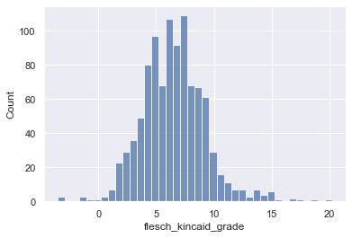

```python
sns.set(style="darkgrid")
sns.histplot(data=speeches, x="flesch_kincaid_grade")
plt.show()
```

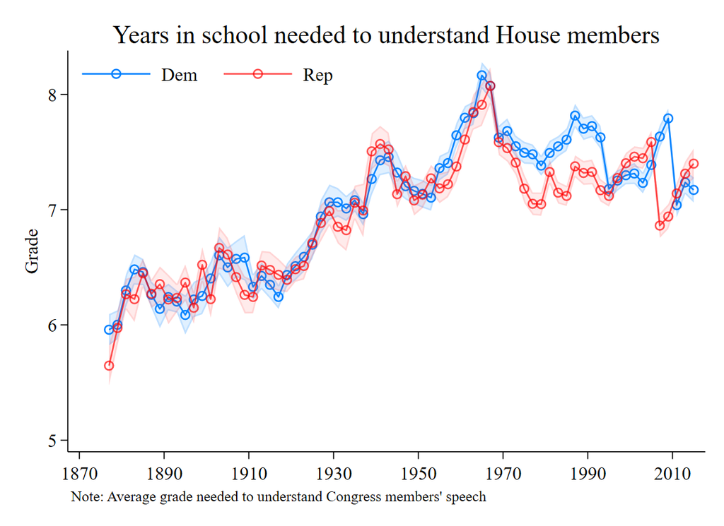

```python
from IPython.display import Image
Image(filename='grade_houseonly_ci.png')
```

# 2. Count matrices and TF-IDF

## 2.1. Cleaning text data

## 2.1.1. Removing other characters than letters

```python
def remove_non_alphabet_characters(text_in):
    import re
    regex = re.compile('[^a-zA-Z]')
    #First parameter is the replacement, second parameter is your input string
    return(regex.sub(' ', text_in))
```

```python
speeches['clean_text'] = speeches.speech.apply(remove_non_alphabet_characters)
# put all in lower case
speeches['clean_text'] = speeches['clean_text'].str.lower()
speeches[['speech', 'clean_text']].head()
```

|  | speech | clean_text |
| --- | --- | --- |
| 0 | Mr. Speaker. I yield myself such time as I may... | mr speaker i yield myself such time as i may... |
| 1 | Mr. Speaker. last Thursday was a very difficul... | mr speaker last thursday was a very difficul... |
| 2 | I now yield to the gentlewoman from California . | i now yield to the gentlewoman from california |
| 3 | I move that the Commi rise. | i move that the commi rise |
| 4 | Mr. COLE. thank you very much for participatin... | mr cole thank you very much for participatin... |

# 2.1.2. Remove Stopwords

```python
# import list of stopwords from nltk
from nltk.corpus import stopwords
print(stopwords.words('english')[:5])
```

```
['i', 'me', 'my', 'myself', 'we']
```

```python
# remove stopwords from text
from nltk.tokenize import word_tokenize
# to split the text by words
def remove_stopwords(text_in):
    word_tokens = word_tokenize(text_in)
    speech_without_stopwords = [w for w in word_tokens if not w.lower() in stopwords.words('english')]
    speech_without_stopwords = ' '.join(speech_without_stopwords)
    return(speech_without_stopwords)
```

```python
speeches['clean_text'] = speeches.clean_text.apply(remove_stopwords)
speeches[['speech', 'clean_text']].head()
```

|  | speech | clean_text |
| --- | --- | --- |
| 0 | Mr. Speaker. I yield myself such time as I may... | mr speaker yield time may consume h r bipartis... |
| 1 | Mr. Speaker. last Thursday was a very difficul... | mr speaker last thursday difficult day beautif... |
| 2 | I now yield to the gentlewoman from California . | yield gentlewoman california |
| 3 | I move that the Commi rise. | move commi rise |
| 4 | Mr. COLE. thank you very much for participatin... | mr cole thank much participating tonight point... |

## 2.1.3. Stem the data

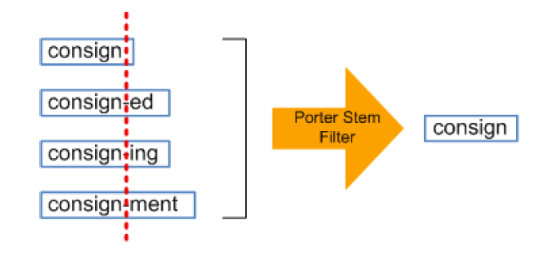

```python
Image(filename='stemmer.png')
```

```python
def stem_the_text(text_in):
    from nltk.stem import SnowballStemmer
    SnowBall = SnowballStemmer('english')
    text_out = ' '.join([SnowBall.stem(word) for word in text_in.split()])
    return(text_out)
```

```python
speeches['clean_text'] = speeches.clean_text.apply(stem_the_text)
speeches[['speech', 'clean_text']].head()
```

|  | speech | clean_text |
| --- | --- | --- |
| 0 | Mr. Speaker. I yield myself such time as I may... | mr speaker yield time may consum h r bipartisa... |
| 1 | Mr. Speaker. last Thursday was a very difficul... | mr speaker last thursday difficult day beauti ... |
| 2 | I now yield to the gentlewoman from California . | yield gentlewoman california |
| 3 | I move that the Commi rise. | move commi rise |
| 4 | Mr. COLE. thank you very much for participatin... | mr cole thank much particip tonight point impo... |

# 2.2. Transform the data into a count matrix of tokens

We want to convert a corpus $D$ to a matrix $X$, using a so-called "bag-of-words" representation.

Each row representing a document $d$, each column the number of time token $x$ is used in that document.

We're going to use unigrams, bigrams and trigrams as tokens (phrases of 1, 2, or 3 words).

For instance: "increase minimum wage" gives: *increase*, *minimum*, *wage*, *increase minimum*, *minimum wage*, and *increase minimum wage*.

```python
from sklearn.feature_extraction.text import CountVectorizer

count_vectorizer = CountVectorizer(min_df=0.005, # remove too unfrequent tokens
                                   max_df=0.5, # remove too frequent tokens
                                   stop_words=stopwords.words('english'),
                                   ngram_range=(1, 3),
                                   token_pattern="[a-zA-Z]+")
```

```python
counts = count_vectorizer.fit_transform(speeches['clean_text'])
vocabulary = np.array(
    [k for (k, v) in sorted(count_vectorizer.vocabulary_.items(),
                            key=lambda kv: kv[1])])
```

```python
count_df = pd.DataFrame.sparse.from_spmatrix(counts)
count_df.columns = vocabulary
count_df.head()
```

|  | abandon | abil | abl | abl get | abort | abraham | abroad | absenc | absenc quorum | absent | ... | york time | young | young children | young man | young men | young peopl | youth | zero | zika | zone |
| --- | --- | --- | --- | --- | --- | --- | --- | --- | --- | --- | --- | --- | --- | --- | --- | --- | --- | --- | --- | --- | --- |
| 0 | 0 | 0 | 0 | 0 | 0 | 0 | 0 | 0 | 0 | 0 | ... | 0 | 0 | 0 | 0 | 0 | 0 | 0 | 0 | 0 | 0 |
| 1 | 0 | 0 | 0 | 0 | 0 | 0 | 0 | 0 | 0 | 0 | ... | 0 | 0 | 0 | 0 | 0 | 0 | 0 | 0 | 0 | 0 |
| 2 | 0 | 0 | 0 | 0 | 0 | 0 | 0 | 0 | 0 | 0 | ... | 0 | 0 | 0 | 0 | 0 | 0 | 0 | 0 | 0 | 0 |
| 3 | 0 | 0 | 0 | 0 | 0 | 0 | 0 | 0 | 0 | 0 | ... | 0 | 0 | 0 | 0 | 0 | 0 | 0 | 0 | 0 | 0 |
| 4 | 0 | 0 | 0 | 0 | 0 | 0 | 0 | 0 | 0 | 0 | ... | 0 | 0 | 0 | 0 | 0 | 0 | 0 | 0 | 0 | 0 |

5 rows × 4058 columns

## How to measure similarity?

We're going to use **cosine similarity**.

Each document is represented by a vector of dimension $V$ (size of the vocabulary).

Similarity between vectors of document $A$ and $B$: $$\frac{\mathbf{A} \cdot \mathbf{B}}{\|\mathbf{A}\|\|\mathbf{B}\|}$$

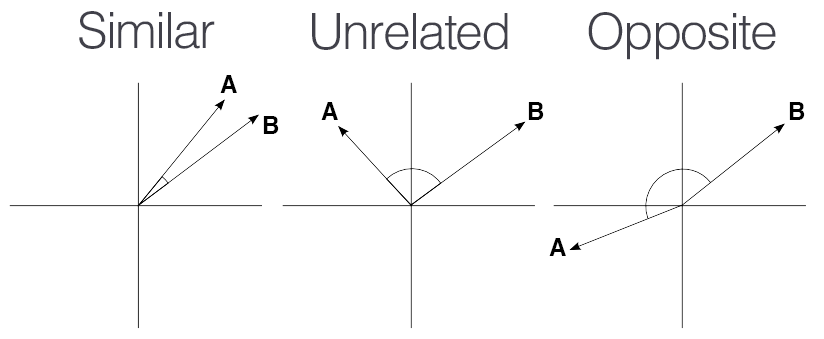

```python
Image(filename='cosine_sim.png')
```

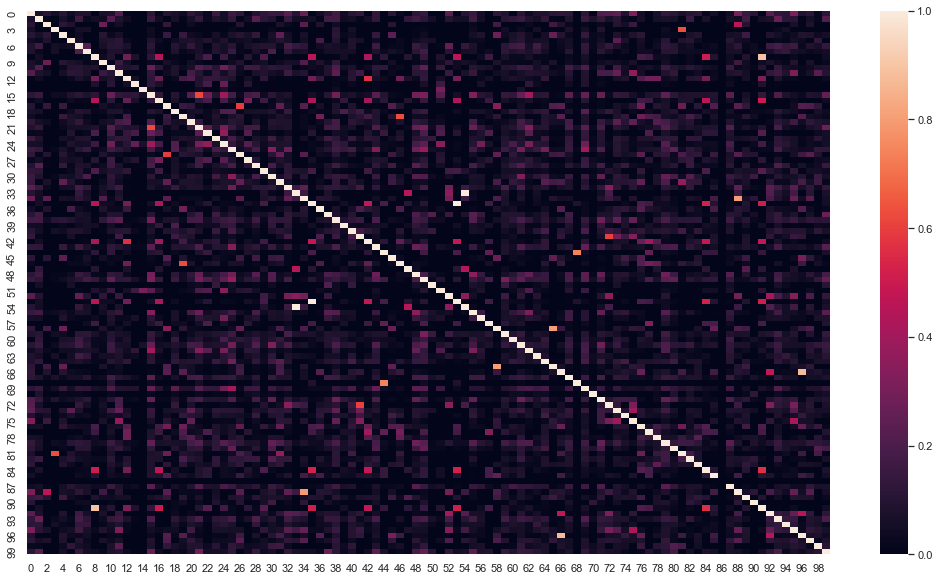

```python
from sklearn.metrics.pairwise import cosine_similarity
sim_df = cosine_similarity(pd.DataFrame.sparse.from_spmatrix(counts))
sns.set(rc = {'figure.figsize':(18,10)})
sns.heatmap(cosine_similarity(pd.DataFrame.sparse.from_spmatrix(counts)[:100]))
```

```python
data = pd.DataFrame(sim_df).merge(pd.DataFrame(speeches['party']), right_index=True, left_index=True)
sim_dem = data[data['party']=='D'].iloc[:,speeches.index[speeches['party'] == 'D'].tolist()].mean().mean()
sim_rep = data[data['party']=='R'].iloc[:,speeches.index[speeches['party'] == 'R'].tolist()].mean().mean()
sim_dem_rep = data[data['party']=='D'].iloc[:,speeches.index[speeches['party'] == 'R'].tolist()].mean().mean()
print('Average similarity across Democrats is '+"%.3f" % sim_dem)
print('Average similarity across Republicans is '+"%.3f" % sim_rep)
print('Average similarity between Democrats and Republicans is '+"%.3f" % sim_dem_rep)
```

```
Average similarity across Democrats is 0.071
Average similarity across Republicans is 0.069
Average similarity between Democrats and Republicans is 0.064
```

## 2.2.2.2. TF-IDF

- Some words are more *meaningful* than others.
- Even after having removed stopwords, some other words might show up very frequently.
- High similarity with just a count matrix counld be driven by Democrats all saying more the word "democratic".
- TF-IDF ("Term-Frequency / Inverse-Document-Frequency") is a simple downgrading technique of words commonly used.

The formula for word $w$ in document $d$ :

$TFIDF_{w,d} = \underbrace{\frac{\text { Count of } w \text { in } d}{\text { Total word count of } d}}_{\text {Term Frequency }} \times \underbrace{\log \left(\frac{\text { Number of documents in } D}{\text { Count of documents containing } w}\right)}_{\text {Inverse Document Frequency }}$

```python
from sklearn.feature_extraction.text import TfidfVectorizer
vectorizer = TfidfVectorizer()
tfidf_matrix = vectorizer.fit_transform(speeches['clean_text'])
```

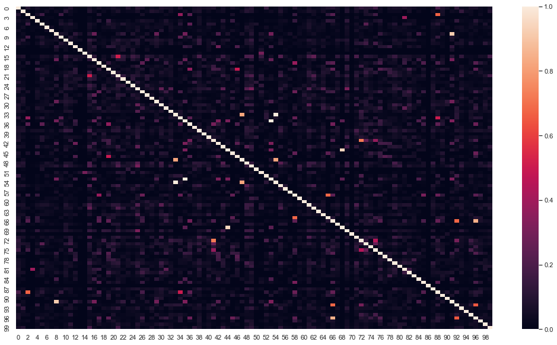

```python
sim_df = cosine_similarity(pd.DataFrame.sparse.from_spmatrix(tfidf_matrix))
sns.set(rc = {'figure.figsize':(18,10)})
sns.heatmap(cosine_similarity(pd.DataFrame.sparse.from_spmatrix(tfidf_matrix)[:100]))
```

```python
data = pd.DataFrame(sim_df).merge(pd.DataFrame(speeches['party']), right_index=True, left_index=True)
sim_dem = data[data['party']=='D'].iloc[:,speeches.index[speeches['party'] == 'D'].tolist()].mean().mean()
sim_rep = data[data['party']=='R'].iloc[:,speeches.index[speeches['party'] == 'R'].tolist()].mean().mean()
sim_dem_rep = data[data['party']=='D'].iloc[:,speeches.index[speeches['party'] == 'R'].tolist()].mean().mean()
print('Average similarity across Democrats is '+"%.3f" % sim_dem)
print('Average similarity across Republicans is '+"%.3f" % sim_rep)
print('Average similarity between Democrats and Republicans is '+"%.3f" % sim_dem_rep)
```

```
Average similarity across Democrats is 0.043
Average similarity across Republicans is 0.045
Average similarity between Democrats and Republicans is 0.039
```

# 3. Dictionary-based approach

- Use some *meaningful* words to impute politicians' positions (e.g. Keyword in context).
- If we know some words that are typically Republican or Democrat we could classify each politician based on how much do they use these words.
- Even if we don't know these words, we could adopt a strategy that find the polarized words and then allocate a score to each politican.
- We're going to define some words that are polarized and use that to classify politicians based on their ideology.
- For each word, we can compute the share of Republican and the share of Democrat who use it.

```python
prop_dem = len(speeches.loc[speeches['party']=='D'])/(len(speeches))
polarization =[]
for wd in vocabulary:
    if speeches.clean_text.str.contains(wd).sum()!=0:
        polarization.append(
            speeches.loc[speeches['party']=='D'].clean_text.str.contains(wd).sum()/speeches.clean_text.str.contains(wd).sum())
    else:
        polarization.append(0)
```

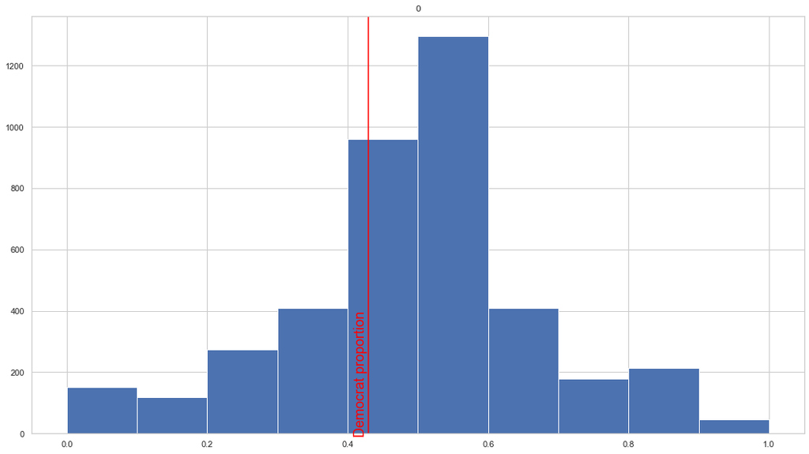

```python
pd.DataFrame(polarization).hist()
plt.axvline(prop_dem,  color='red')
plt.text(prop_dem-0.02,0, 'Democrat proportion', rotation = 90,color = 'red', size=18)
```

```python
# Top Democrat words
vocabulary[[i for i in range(len(polarization)) if polarization[i] != 1 and polarization[i]>0.9]]
```

```
array(['hous republican', 'pollut'], dtype='<U26')
```

```python
# Top Republican words
vocabulary[[i for i in range(len(polarization)) if polarization[i] != 0 and polarization[i]<0.1]]
```

[output not shown]

### Compute ideology of each politician as the average ideology of the words they use.

```python
speeches = speeches.rename(columns={'speech':'initial_speech'})

combined_df = pd.concat([pd.DataFrame.sparse.from_spmatrix(counts), speeches], axis=1)
column_name = list(vocabulary) + list(speeches.columns)
combined_df.columns = column_name
combined_df['tot_count'] = combined_df[list(vocabulary)].sum(axis=1)
```

```python
# weight the counts by word ideology
for i, pol in enumerate(polarization):
    combined_df[vocabulary[i]]=combined_df[vocabulary[i]].apply(lambda x: x*pol)
```

```python
# weighted sum
combined_df['tot_pola'] = combined_df[list(vocabulary)].sum(axis=1)
combined_df['ideology'] = combined_df['tot_pola']/combined_df['tot_count']
ideology_df = combined_df[['speakerid', 'party', 'ideology']].groupby(by=['speakerid', 'party'], as_index=False).mean()
```

```python
ideo_dem = ideology_df[ideology_df['party']=='D'].ideology.mean()
ideo_rep = ideology_df[ideology_df['party']=='R'].ideology.mean()
print('Average ideology among Democrats is '+"%.3f" % ideo_dem)
print('Average ideology among Republicans is '+"%.3f" % ideo_rep)
```

```
Average ideology among Democrats is 0.511
Average ideology among Republicans is 0.441
```

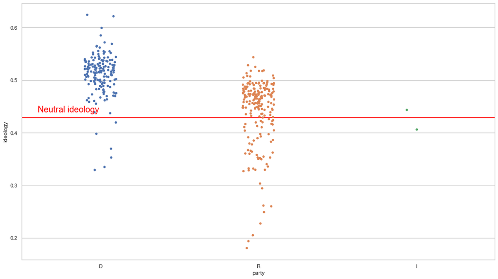

```python
import seaborn as sns
sns.set_theme(style="whitegrid")
ax = sns.stripplot(x="party", y="ideology", data=ideology_df)
plt.axhline(prop_dem,  color='red')

plt.text(-0.4,prop_dem+0.01, 'Neutral ideology', color = 'red', size=18)
```

But: This measure is subject to **finite-sample bias**: sample of realized speeches is limited: "the number of phrases a speaker could choose is large relative to the total amount of speech we observe, so many phrases are said mostly by one party or the other purely by chance." (see Gentzkow, Shapiro, and Taddy (2019))

A more accurate measure of partisanship/ideology of each phrase: "posterior probability that an observer with a neutral prior expects to assign to a speaker’s true party after hearing the speaker utter a single phrase."

# 4. Topic model

Today, we're going to focus on **Latent Dirichlet Allocation** (Blei, 2003), one of the most commonly used topic models.

- $D$ documents with $V$ unique terms
- $K$ topics, with probability vectors $\beta_{kv}$ over $V$
- Each document $d$ is composed of multiple topics with shares $\theta_{dk}$
- Probability that word $v$ is used in document $d$: $p_{dv}=\sum_k\beta_{kv}\theta_{dk}$
- From $V$ dimensions to $K$ dimensions
- Dirichlet priors
- Posterior approximated by MCMC

```python
import gensim
import gensim.corpora as corpora

n_topics_in=10
num_words_in = 20

df_in = speeches.clean_text.str.split()

id2word = corpora.Dictionary(df_in)
id2word.filter_extremes(no_below=5, no_above=0.3)
corpus = [id2word.doc2bow(text) for text in df_in]

ldamodel = gensim.models.ldamodel.LdaModel(
    corpus, num_topics=n_topics_in, id2word=id2word, passes=15)
```

```python
topic_proportions.columns =['prop_topic0', 'prop_topic1', 'prop_topic2', 'prop_topic3', 'prop_topic4', 'prop_topic5', 'prop_topic6', 'prop_topic7', 'prop_topic8', 'prop_topic9']
topic_proportions.head()
```

[output not shown]

|  | prop_topic0 | prop_topic1 | prop_topic2 | prop_topic3 | prop_topic4 | prop_topic5 | prop_topic6 | prop_topic7 | prop_topic8 | prop_topic9 |
| --- | --- | --- | --- | --- | --- | --- | --- | --- | --- | --- |
| 0 | 0.001316 | 0.315438 | 0.001317 | 0.001316 | 0.379725 | 0.001317 | 0.259775 | 0.001317 | 0.037207 | 0.001317 |
| 1 | 0.000532 | 0.023619 | 0.190368 | 0.098837 | 0.000532 | 0.649576 | 0.000532 | 0.034949 | 0.000532 | 0.000532 |
| 2 | 0.033334 | 0.033335 | 0.033334 | 0.033334 | 0.033334 | 0.033335 | 0.033336 | 0.699990 | 0.033334 | 0.033334 |
| 3 | 0.033340 | 0.033342 | 0.033347 | 0.033344 | 0.033349 | 0.699910 | 0.033346 | 0.033345 | 0.033342 | 0.033338 |
| 4 | 0.008336 | 0.008336 | 0.008337 | 0.008336 | 0.008337 | 0.328124 | 0.362228 | 0.251271 | 0.008336 | 0.008336 |

```python
# make word clouds for the topics
for i,weights in ldamodel.show_topics(num_topics=-1,
                                 num_words=100,
                                 formatted=False):
    maincol = randint(0,360)
    wordcloud = WordCloud(background_color="white",
                          ranks_only=False,
                          max_font_size=120,
                          color_func=colorfunc,
                          height=600,width=800).generate_from_frequencies(dict(weights))

    plt.clf()
    plt.figure(figsize=(2, 2))
    plt.imshow(wordcloud,interpolation="bilinear")
    plt.axis("off")
    plt.show()
```

[output not shown]

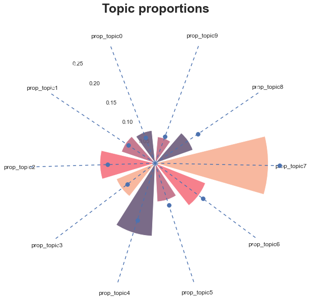

```python
from textwrap import wrap

# Initialize layout in polar coordinates
fig, ax = plt.subplots(figsize=(9, 12.6), subplot_kw={"projection": "polar"})

# Set background color to white, both axis and figure.
fig.patch.set_facecolor("white")
ax.set_facecolor("white")
ax.set_theta_offset(1.2 * np.pi / 2)
ax.set_ylim(0, 0.25)

# Add geometries to the plot -------------------------------------
# See the zorder to manipulate which geometries are on top
ANGLES = np.linspace(0.05, 2 * np.pi - 0.05, 10, endpoint=False)
LENGTHS = topic_proportions.loc[topic_proportions['party']=='D', name_col].mean().values.flatten().tolist()
COLORS = ["#6C5B7B","#C06C84","#F67280","#F8B195"]
MEAN_GAIN = topic_proportions[name_col].mean().values.flatten().tolist()

# Add bars to represent the topic proportions
ax.bar(ANGLES, LENGTHS, color=COLORS, alpha=0.9, width=0.52, zorder=10)

# Add dashed vertical lines. These are just references
ax.vlines(ANGLES, 0, 3000, ls=(0, (4, 4)), zorder=11)

# Add dots to represent the mean gain
ax.scatter(ANGLES, MEAN_GAIN, s=60, zorder=11)

# Add labels for the topics  -------------------------------------
REGION = ["\n".join(wrap(r, 5, break_long_words=False)) for r in name_col]

# Set the labels
fig.text(0.35, 0.83, "Topic proportions", fontsize=25, weight="bold", ha="left", va="baseline")

ax.set_xticks(ANGLES)
ax.set_xticklabels(REGION, size=12);
```

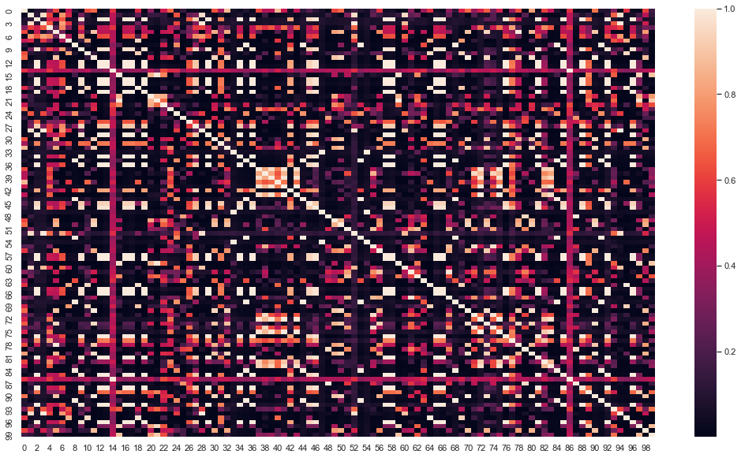

```python
sim_df = cosine_similarity(pd.DataFrame(topic_proportions))
sns.set(rc = {'figure.figsize':(18,10)})
sns.heatmap(cosine_similarity(pd.DataFrame(topic_proportions)[:100]))
```

```python
data = pd.DataFrame(sim_df).merge(pd.DataFrame(speeches['party']), right_index=True, left_index=True)
sim_dem = data[data['party']=='D'].iloc[:,speeches.index[speeches['party'] == 'D'].tolist()].mean().mean()
sim_rep = data[data['party']=='R'].iloc[:,speeches.index[speeches['party'] == 'R'].tolist()].mean().mean()
sim_dem_rep = data[data['party']=='D'].iloc[:,speeches.index[speeches['party'] == 'R'].tolist()].mean().mean()
print('Average similarity across Democrats is '+"%.3f" % sim_dem)
print('Average similarity across Republicans is '+"%.3f" % sim_rep)
print('Average similarity between Democrats and Republicans is '+"%.3f" % sim_dem_rep)
```

```
Average similarity across Democrats is 0.233
Average similarity across Republicans is 0.233
Average similarity between Democrats and Republicans is 0.227
```

# 5. Embedding

## 5.1. Word embedding:

- Dimension reduction approach in deep learning models
- Map semantic concepts into a vector space

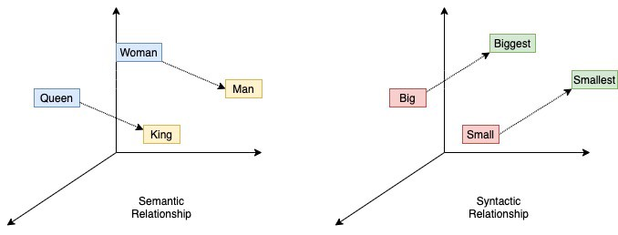

```python
# Image from Nikhil Birajdar
Image(filename='word2vec.jpeg')
```

## 5.2. Document embedding:

```python
import gensim
import gensim.downloader as api
from gensim.models.doc2vec import Doc2Vec, TaggedDocument
sample_text = api.load("text8")
common_texts = [d for d in sample_text]
#common_documents = [TaggedDocument(doc, [i]) for i, doc in enumerate(common_texts)]
#model1 = Doc2Vec(common_documents, vector_size=5, window=2, min_count=1, workers=4)

def tagged_document(list_of_list_of_words):
    for i, list_of_words in enumerate(list_of_list_of_words):
        yield gensim.models.doc2vec.TaggedDocument(list_of_words, [i])
data_training = list(tagged_document(common_texts))
model = gensim.models.doc2vec.Doc2Vec(vector_size=40, min_count=2, epochs=30)
model.build_vocab(data_training)
```

```python
vector_test = model.infer_vector(
    [word for word in 'minimum wage needs to be increased to improve worker conditions'])

vector_test2 = model.infer_vector(
    [word for word in 'corporate taxes should be considerably lowered to enhance business creations'])
```

```python
from scipy import spatial

similarity = 1 - spatial.distance.cosine(vector_test, vector_test2)
print(similarity)
```

```
-0.14862491190433502
```